# R Notebook

# Homework - Week 10 - Weekend

## Part 1 - Questions

**1** I want to predict how well 6 year-olds are going to do in their final school exams. Using the following variables am I likely under-fitting, fitting well or over-fitting? Postcode, gender, reading level, score in maths test, date of birth, family income.

*Answer*: You are likely overfitting, as variables like postcode, gender, date of birth and family income might help in explaining data for a particular training dataset. These variables have likely not much to do with exam results for 6-year olds outside the training set.

**2** If I have two models, one with an AIC score of 34,902 and the other with an AIC score of 33,559 which model should I use?

*Answer*: For AIC scores: the lower the better. So in this case a model with AIC 33,559.

**3** I have two models, the first with: r-squared: 0.44, adjusted r-squared: 0.43. The second with: r-squared: 0.47, adjusted r-squared: 0.41. Which one should I use?

*Answer*: The adjusted r-squared gives the r-squared value but adjusted for the amount of variables you include in your model (and therefore penalising superfluous complexity) Go for model 1!

**4** I have a model with the following errors: RMSE error on test set: 10.3, RMSE error on training data: 10.4. Do you think this model is over-fitting?

*Answer*: Residual mean squared error (RMSE) gives the average error of predictions (either on the test or train set). You expect this to be smaller on the train set, and slightly higher on the test set. If higher on the train set, than the model might be underfitting!

**5** How does k-fold validation work?

*Answer*: Instead of splitting your data in a test set and a train set, you now split your data in 5 equal folds. You create a model for 4 folds (and exclude 1 different fold each time). You repeat this 5 times. You get 5 best models for each run, ideally this should give one similar model. You test this model on the 5 different test folds and compare the results, and pick the best performing model.

**6** What is a validation set? When do you need one?

*Answer*: When you split your data into a train set (data set used to create, train, a model) and a test set. You use this test data set to test the performance of your model and potentially compare several models. This test data set is also called validation set.

**7** Describe how backwards selection works.

*Answer*: In automated model selection the algorithm starts creating a model including all variables. Each next step a variable is removed from the list of predictors and compared with the previous model. In the end the best model is found. This method is called backwards selection. = you start with everything, and slowly reduce number of variables.

**8** Describe how best subset selection works.

*Answer*: Best subset selection is also called exhaustive search. Models are created of all different possible combinations of predictors, and performance is compared with each other. The best model based on the best subset is selected.

## Part 2 - Model Building

For this exercise I will perform manual step-wise regression, building a explanatory multiple linear regression model.

**Goal:** model the quality of the wines. Use regression to determine which physiochemical properties make a wine ‘good’!

```r
library(tidyverse)
library(GGally)
library(modelr)
library(skimr)
library(ggfortify)
```

### first step: Approach to measure success and prevent overfitting

1. Goodness of fit measures I use: (adjusted) r-squared, AIC/BIC
2. let’s create a Train-Test split with 90:10 ratio

```r
red_wine <- read_csv("data/wine_quality_red.csv")
white_wine <- read_csv("data/wine_quality_white.csv")
# first for the red_wine:
#. 1. Total rows:
n_data_red <- nrow(red_wine)
# test index:
test_index_red <- sample(1:n_data_red, size = n_data_red*0.1)
# use test index to create test and train set:
test_red <- slice(red_wine, test_index_red)
train_red <- slice(red_wine, -test_index_red)

# Same for white:
n_data_white <- nrow(white_wine)
test_index_white <- sample(1:n_data_white, size = n_data_white*0.1)
test_white <- slice(white_wine, test_index_white)
train_white <- slice(white_wine, -test_index_white)
```

### Data exploration

```r
# data exploration

head(train_red)
```

| wine_id | fixed_acidity | volatile_acidity | citric_acid | residual_sugar | chlorides | free_sulfur_dioxide | total_sulfur_dioxide | density | p_h | sulphates | alcohol | quality | region |
| --- | --- | --- | --- | --- | --- | --- | --- | --- | --- | --- | --- | --- | --- |
| 1 | 7.4 | 0.70 | 0.00 | 1.9 | 0.076 | 11 | 34 | 0.9978 | 3.51 | 0.56 | 9.4 | 4.66 | Australia |
| 2 | 7.8 | 0.88 | 0.00 | 2.6 | 0.098 | 25 | 67 | 0.9968 | 3.20 | 0.68 | 9.8 | 4.82 | Spain |
| 3 | 7.8 | 0.76 | 0.04 | 2.3 | 0.092 | 15 | 54 | 0.9970 | 3.26 | 0.65 | 9.8 | 4.91 | Spain |
| 4 | 11.2 | 0.28 | 0.56 | 1.9 | 0.075 | 17 | 60 | 0.9980 | 3.16 | 0.58 | 9.8 | 5.96 | Australia |
| 5 | 7.4 | 0.70 | 0.00 | 1.9 | 0.076 | 11 | 34 | 0.9978 | 3.51 | 0.56 | 9.4 | 5.42 | Italy |
| 7 | 7.9 | 0.60 | 0.06 | 1.6 | 0.069 | 15 | 59 | 0.9964 | 3.30 | 0.46 | 9.4 | 5.09 | USA |

```r
skim(train_red) %>%
  view()
dim(train_red)
```

```
[1] 1440   14
```

```r
# 1599   14 - 1440   14

head(train_white)
```

| wine_id | fixed_acidity | volatile_acidity | citric_acid | residual_sugar | chlorides | free_sulfur_dioxide | total_sulfur_dioxide | density | p_h | sulphates | alcohol | quality | region |
| --- | --- | --- | --- | --- | --- | --- | --- | --- | --- | --- | --- | --- | --- |
| 1 | 7.0 | 0.27 | 0.36 | 20.7 | 0.045 | 45 | 170 | 1.0010 | 3.00 | 0.45 | 8.8 | 5.92 | Australia |
| 2 | 6.3 | 0.30 | 0.34 | 1.6 | 0.049 | 14 | 132 | 0.9940 | 3.30 | 0.49 | 9.5 | 6.06 | Australia |
| 3 | 8.1 | 0.28 | 0.40 | 6.9 | 0.050 | 30 | 97 | 0.9951 | 3.26 | 0.44 | 10.1 | 6.25 | Spain |
| 5 | 7.2 | 0.23 | 0.32 | 8.5 | 0.058 | 47 | 186 | 0.9956 | 3.19 | 0.40 | 9.9 | 6.35 | USA |
| 6 | 8.1 | 0.28 | 0.40 | 6.9 | 0.050 | 30 | 97 | 0.9951 | 3.26 | 0.44 | 10.1 | 5.82 | Italy |
| 7 | 6.2 | 0.32 | 0.16 | 7.0 | 0.045 | 30 | 136 | 0.9949 | 3.18 | 0.47 | 9.6 | 5.53 | Australia |

```r
skim(train_white) %>%
  view()
dim(train_white)
```

```
[1] 4409   14
```

```r
# 4898   14 - 4409   14
```

Based on the above, a few points: Red wine: 1. Our dependent/outcome variable, y, is ‘quality’ 2. column ‘p_h_’ is a scale, and so is quality 3. non-informative columns are: ‘wine_id’, and ‘region’ (we do not want to base quality on just the country) 4. likely total_sulfur_dioxide not of interest as its free SO2 over 50ppm that influences taste (according to info) 5. positive distribution in: alcohol, sulphates, total/free_sulphur, chlorides, residual sugar, citric_acid, volatile_acidity

White wine: 1. same as above, except positive distribution in: density, total_SO2, volatile_acidity, fixed_acidity, citric_acid, residual_sugar, chlorides

A data manipulation step might be needed for the positive distributed variables.

-> Each row represents one wine -> most variables (acidity, sugar, cholorides, SO2, density, sulphates) all in unit per dm^3 -> alcohol in percentage, PH on scale

### Data wrangling

Goal is to build a general model to understand what properties make a wine good. We want to do this for all types of wines, lets combine datasets and add wine type as a factor.

```r
red_wine_type <- train_red %>%
  mutate(is_red = TRUE) %>%
  select(-wine_id)

white_wine_type <- train_white %>%
  mutate(is_red = FALSE) %>%
  select(-wine_id)

#remove region
wine_total <-
  bind_rows(white_wine_type, red_wine_type) %>%
  select(-region)

wine_total
```

| fixed_acidity | volatile_acidity | citric_acid | residual_sugar | chlorides | free_sulfur_dioxide | total_sulfur_dioxide | density | p_h | sulphates | alcohol | quality | is_red |
| --- | --- | --- | --- | --- | --- | --- | --- | --- | --- | --- | --- | --- |
| 7.0 | 0.270 | 0.36 | 20.70 | 0.045 | 45.0 | 170.0 | 1.00100 | 3.00 | 0.45 | 8.8 | 5.92 | FALSE |
| 6.3 | 0.300 | 0.34 | 1.60 | 0.049 | 14.0 | 132.0 | 0.99400 | 3.30 | 0.49 | 9.5 | 6.06 | FALSE |
| 8.1 | 0.280 | 0.40 | 6.90 | 0.050 | 30.0 | 97.0 | 0.99510 | 3.26 | 0.44 | 10.1 | 6.25 | FALSE |
| 7.2 | 0.230 | 0.32 | 8.50 | 0.058 | 47.0 | 186.0 | 0.99560 | 3.19 | 0.40 | 9.9 | 6.35 | FALSE |
| 8.1 | 0.280 | 0.40 | 6.90 | 0.050 | 30.0 | 97.0 | 0.99510 | 3.26 | 0.44 | 10.1 | 5.82 | FALSE |
| 6.2 | 0.320 | 0.16 | 7.00 | 0.045 | 30.0 | 136.0 | 0.99490 | 3.18 | 0.47 | 9.6 | 5.53 | FALSE |
| 7.0 | 0.270 | 0.36 | 20.70 | 0.045 | 45.0 | 170.0 | 1.00100 | 3.00 | 0.45 | 8.8 | 6.17 | FALSE |
| 6.3 | 0.300 | 0.34 | 1.60 | 0.049 | 14.0 | 132.0 | 0.99400 | 3.30 | 0.49 | 9.5 | 6.08 | FALSE |
| 8.1 | 0.220 | 0.43 | 1.50 | 0.044 | 28.0 | 129.0 | 0.99380 | 3.22 | 0.45 | 11.0 | 5.86 | FALSE |
| 8.1 | 0.270 | 0.41 | 1.45 | 0.033 | 11.0 | 63.0 | 0.99080 | 2.99 | 0.56 | 12.0 | 4.91 | FALSE |

[output cut: 990 more lines]

```r
#missing values?
wine_total %>%
  summarise(across(.fns = ~sum(is.na(.x))))
```

| fixed_acidity | volatile_acidity | citric_acid | residual_sugar | chlorides | free_sulfur_dioxide | total_sulfur_dioxide | density | p_h | sulphates | alcohol | quality | is_red |
| --- | --- | --- | --- | --- | --- | --- | --- | --- | --- | --- | --- | --- |
| 0 | 0 | 0 | 0 | 0 | 0 | 0 | 0 | 0 | 0 | 0 | 0 | 0 |

```r
# no missing data!

# check for aliased variables:
alias(quality ~ ., data = wine_total)
```

```
Model :
quality ~ fixed_acidity + volatile_acidity + citric_acid + residual_sugar +
    chlorides + free_sulfur_dioxide + total_sulfur_dioxide +
    density + p_h + sulphates + alcohol + is_red
```

```r
# none
```

### Check correlations

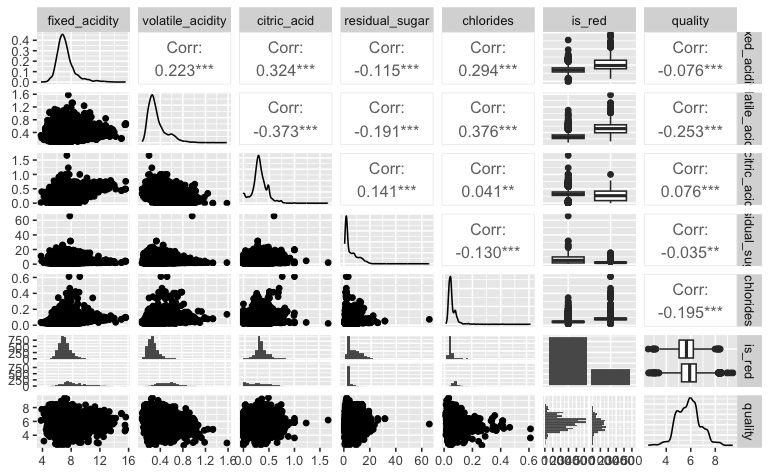

```r
# lets explore ggpairs but by splitting variables in two sets

wine_total_1 <- wine_total %>%
  select(fixed_acidity:chlorides, is_red, quality)

wine_total_2 <- wine_total %>%
  select(free_sulfur_dioxide:is_red)

ggpairs(wine_total_1)
```

In first set: - highest correlation with quality is: volatile_acidity and chlorides - interesting interaction between is_red and acidity types..

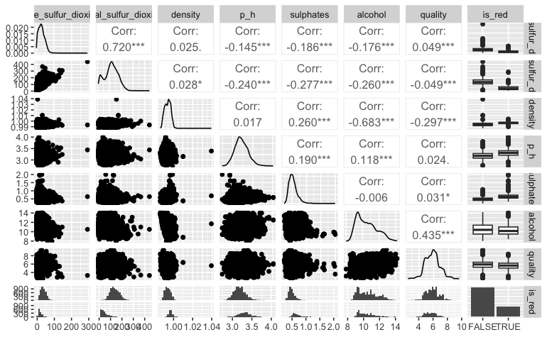

```r
ggpairs(wine_total_2)
```

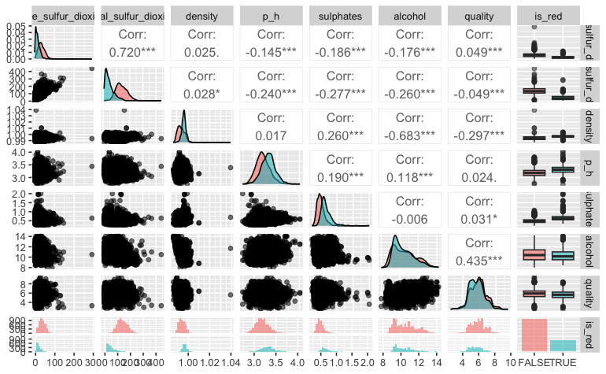

```r
wine_total_2 %>%
  ggpairs(aes(fill = is_red, alpha = 0.4, bins = 25))
```

In second set: - highest correlation with quality is: alcohol and density - interesting interaction between is_red and ph and SO2 (free and residual)

[figure not shown]

### Feature engineering part 2

Based on above distributions, I want to check data after transforming: log(residual_sugar) log(chlorides) log(total_sulfur_dioxide) log(free_sulfur_dioxide)

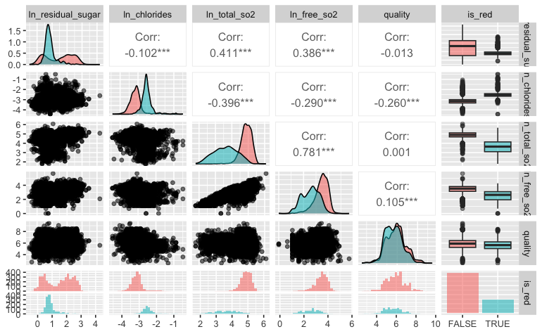

```r
wine_total_transform <- wine_total %>%
  mutate(ln_residual_sugar = log(residual_sugar),
         ln_chlorides = log(chlorides),
         ln_total_so2 = log(total_sulfur_dioxide),
         ln_free_so2 = log(free_sulfur_dioxide))

wine_total_transform %>%
  select(ln_residual_sugar:ln_free_so2, quality, is_red) %>%
  ggpairs(aes(fill = is_red, alpha = 0.4, bins = 25))
```

We now see that there is a stronger correlation with log(chlorides) than before. For the rest it did not differ a lot. -> So might be a good idea to add chlorides as log transform

Rest did not change much.

We also see now that total_SO2 and free_SO2 are strongly correlated with each other. We might only want to keep free SO2 as its free SO2 over 50ppm that influences taste (according to info)